# Biodiversity across a salinity gradient

# Rarefaction Curves

## `ggiNEXT` Rarefaction Curves

```r
# Prepare Colors
color_df <-
  iNEXT_input_df %>%
  colnames() %>%
  data.frame()
# Check
head(color_df)
```

```
##             .
## 1 SRR19509095
## 2 SRR19509096
## 3 SRR19509097
## 4 SRR19509098
## 5 SRR19509099
## 6 SRR19509100
```

```r
# Rename the column
colnames(color_df)[1] <- "names"
# Check
head(color_df)
```

```
##         names
## 1 SRR19509095
## 2 SRR19509096
## 3 SRR19509097
## 4 SRR19509098
## 5 SRR19509099
## 6 SRR19509100
```

```r
## fix metadata names to have 6 groups
#### Chatgpt: add snail_exp_group_name, for the six experimental groups
metadata_df <- metadata_df %>%
  mutate(snail_exp_group_name = substr(Sample.Name, 1, 2))


# Make a helper dataframe for plotting with colors
iNEXT_color_df <-
  color_df %>%
  # Fix the names for merging
  mutate(names = gsub(names, pattern = "[.]", replace = "-"),
         names = gsub(names, pattern = "X",  replace = "")) %>%
  # Merge with metadata
  left_join(metadata_df, by = "names") %>%
  # Merge with colors for plotting with ggiNEXT    ###
  left_join(data.frame(station_colors = station_colors,
            snail_exp_group_name = names(station_colors)),
            by = "snail_exp_group_name")

head(iNEXT_color_df)
```

```
##         names Assay.Type AvgSpotLen    Bases  BioProject    BioSample
## 1 SRR19509095   AMPLICON        500 54925500 PRJNA843708 SAMN28766924
## 2 SRR19509096   AMPLICON        500 50099000 PRJNA843708 SAMN28766923
## 3 SRR19509097   AMPLICON        500 55474000 PRJNA843708 SAMN28766922
## 4 SRR19509098   AMPLICON        500 55287500 PRJNA843708 SAMN28766921
## 5 SRR19509099   AMPLICON        500 57233000 PRJNA843708 SAMN28766974
## 6 SRR19509100   AMPLICON        500 54169000 PRJNA843708 SAMN28766973
##                BioSampleModel    Bytes                 Center.Name
## 1 Metagenome or environmental 18249721 NANJING FORESTRY UNIVERSITY
## 2 Metagenome or environmental 16578763 NANJING FORESTRY UNIVERSITY
## 3 Metagenome or environmental 18304676 NANJING FORESTRY UNIVERSITY
## 4 Metagenome or environmental 18219402 NANJING FORESTRY UNIVERSITY
## 5 Metagenome or environmental 18702068 NANJING FORESTRY UNIVERSITY
## 6 Metagenome or environmental 17860015 NANJING FORESTRY UNIVERSITY
##   Collection_Date Consent DATASTORE.filetype DATASTORE.provider
```

[output cut: 48 more lines]

### Plotting rarefaction

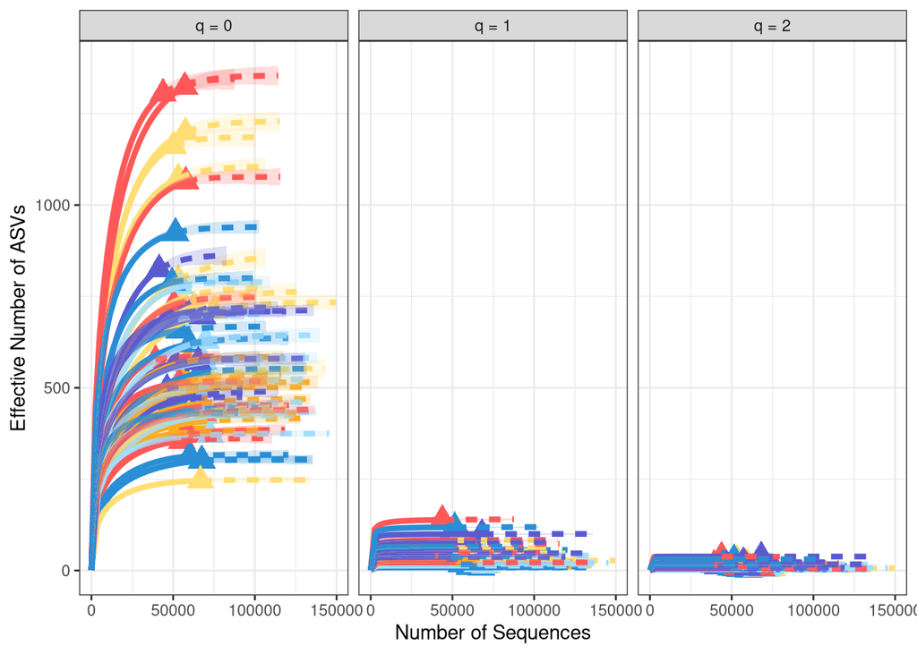

```r
ggiNEXT(iNEXT_data, type = 1, facet.var = "Order.q") +
  scale_color_manual(values = iNEXT_color_df$station_colors) +
  scale_fill_manual(values = iNEXT_color_df$station_colors) +
  scale_shape_manual(values = base::rep(17, nsamples(midpoint_rooted_physeq))) +
  theme_bw() +
  theme(legend.position = "none") +
  labs(y = "Effective Number of ASVs", x = "Number of Sequences")
```

### Manually plotting rarefaction

```r
str(iNEXT_data)
```

```
## List of 3
##  $ DataInfo:'data.frame':    60 obs. of  14 variables:
##   ..$ Assemblage: chr [1:60] "SRR19509095" "SRR19509096" "SRR19509097" "SRR19509098" ...
##   ..$ n         : num [1:60] 67014 51886 63907 58117 53191 ...
##   ..$ S.obs     : num [1:60] 457 375 406 519 795 723 711 739 529 418 ...
##   ..$ SC        : num [1:60] 0.999 1 1 0.999 0.998 ...
##   ..$ f1        : num [1:60] 39 27 34 50 134 105 82 101 75 40 ...
##   ..$ f2        : num [1:60] 59 44 54 65 123 125 143 138 111 85 ...
##   ..$ f3        : num [1:60] 32 39 39 51 85 66 73 94 50 42 ...
##   ..$ f4        : num [1:60] 26 14 22 36 58 46 47 49 30 26 ...
##   ..$ f5        : num [1:60] 15 11 8 17 44 33 35 29 20 15 ...
##   ..$ f6        : num [1:60] 13 6 13 15 21 30 30 27 18 8 ...
##   ..$ f7        : num [1:60] 8 9 11 6 27 18 17 30 14 17 ...
##   ..$ f8        : num [1:60] 9 5 8 11 18 29 14 16 9 11 ...
##   ..$ f9        : num [1:60] 8 8 7 9 16 21 20 17 11 5 ...
##   ..$ f10       : num [1:60] 9 6 6 9 15 14 16 17 10 9 ...
##  $ iNextEst:List of 2
##   ..$ size_based    :'data.frame':   7200 obs. of  10 variables:
##   .. ..$ Assemblage: chr [1:7200] "SRR19509095" "SRR19509095" "SRR19509095" "SRR19509095" ...
##   .. ..$ m         : num [1:7200] 1 3723 7446 11169 14892 ...
##   .. ..$ Method    : chr [1:7200] "Rarefaction" "Rarefaction" "Rarefaction" "Rarefaction" ...
##   .. ..$ Order.q   : num [1:7200] 0 0 0 0 0 0 0 0 0 0 ...
##   .. ..$ qD        : num [1:7200] 1 230 293 328 353 ...
##   .. ..$ qD.LCL    : num [1:7200] 1 228 289 324 348 ...
##   .. ..$ qD.UCL    : num [1:7200] 1 233 296 332 357 ...
##   .. ..$ SC        : num [1:7200] 0.224 0.976 0.988 0.992 0.994 ...
##   .. ..$ SC.LCL    : num [1:7200] 0.222 0.975 0.988 0.992 0.994 ...
##   .. ..$ SC.UCL    : num [1:7200] 0.226 0.977 0.988 0.993 0.995 ...
##   ..$ coverage_based:'data.frame':   7200 obs. of  8 variables:
##   .. ..$ Assemblage: chr [1:7200] "SRR19509095" "SRR19509095" "SRR19509095" "SRR19509095" ...
##   .. ..$ SC        : num [1:7200] 0.224 0.976 0.988 0.992 0.994 ...
##   .. ..$ m         : num [1:7200] 1 3723 7446 11169 14892 ...
##   .. ..$ Method    : chr [1:7200] "Rarefaction" "Rarefaction" "Rarefaction" "Rarefaction" ...
##   .. ..$ Order.q   : num [1:7200] 0 0 0 0 0 0 0 0 0 0 ...
##   .. ..$ qD        : num [1:7200] 1 230 293 328 353 ...
##   .. ..$ qD.LCL    : num [1:7200] 0.996 226.344 287.51 322.345 346.221 ...
##   .. ..$ qD.UCL    : num [1:7200] 1 234 298 334 359 ...
##  $ AsyEst  :'data.frame':    180 obs. of  7 variables:
##   ..$ Assemblage: chr [1:180] "SRR19509095" "SRR19509095" "SRR19509095" "SRR19509096" ...
##   ..$ Diversity : chr [1:180] "Species richness" "Shannon diversity" "Simpson diversity" "Species richness" ...
##   ..$ Observed  : num [1:180] 457 15.42 4.46 375 24.51 ...
##   ..$ Estimator : num [1:180] 469.89 15.48 4.46 383.28 24.61 ...
##   ..$ s.e.      : num [1:180] 9.7619 0.1469 0.0272 7.6015 0.2039 ...
##   ..$ LCL       : num [1:180] 457 15.2 4.4 375 24.2 ...
##   ..$ UCL       : num [1:180] 489.02 15.77 4.51 398.18 25.01 ...
##  - attr(*, "class")= chr "iNEXT"
```

```r
iNEXT_manual_df <-
  iNEXT_data$iNextEst$size_based %>%
  dplyr::rename(names = Assemblage) %>%
  # fix the samples to merge with metadata
  mutate(names = gsub(names, pattern = "[.]", replace = "-"),
         names = gsub(names, pattern = "X", replace = "")) %>%
  # join with the metadata
  left_join(., metadata_df, by = "names") %>%              #### Changed "station" to "snail_exp_group_name"
  mutate(snail_exp_group_name = factor(snail_exp_group_name, levels = c("CF",
                                              "LF",
                                              "HF",
                                              "CM",
                                              "LM",
                                              "HM")))

# Inspection
dim(iNEXT_manual_df)
```

```
## [1] 7200   48
```

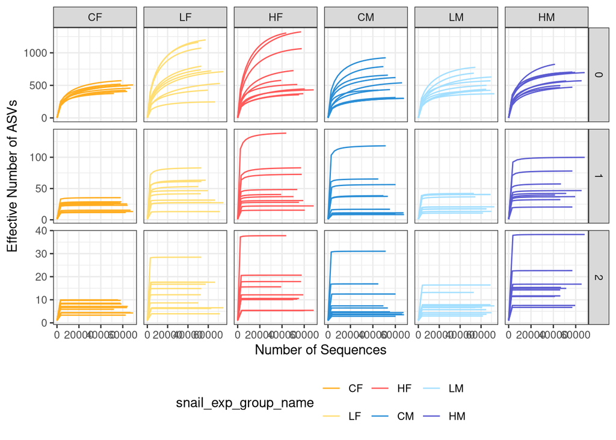

```r
# Manually plot rarefaction curves
iNEXT_manual_df %>%
  # Filter out rows that are calculated with actual sequences (no extrapolated)
  dplyr::filter(Method == "Rarefaction") %>%
  # Now, let's draw the plot!
  ggplot(aes(x = m, y = qD, color = snail_exp_group_name, group = names)) +  #Changed "station" to "snail_exp_group_name"
  geom_line() +
  # Facet by station
  facet_grid(Order.q~snail_exp_group_name, scales = "free") +               #Changed "station" to "snail_exp_group_name"
  scale_color_manual(values = station_colors) +
  theme_bw() +
  labs(y = "Effective Number of ASVs", x = "Number of Sequences") +
  theme(legend.position = "bottom")
```

INTERPRETATION #1: What can you conclude from the ggiNEXT and manual rarefaction curve plots? Are there “enough” sequences to analyze the samples? Is it valid to make any conclusions about species richness when q = 0? What about when q = 1? Or q = 2? Why or why not?

I think it is safe to say that for q = 1 and q = 2, which emphasize the common and dominant species, enough sequences have been sampled. In all 6 experimental groups (control, high-temperature, low-temperature vs female, male), all rarefaction curves plateau.

For richness, the low and high temperature female groups (LF and HF) definitely don’t plateau. There are several samples in these two groups that do not asymptote. in FLF and HF, there is even a slight bimodal distribution. Because these values don’t plateau, we can’t say anything about the richness.

For shannon, the trends are more amplified in HF, where the samples that didn’t asymptote have extremely high number of ASVs that are moderately abundant. HF and CM (control-temperature male) have an outlier.

For simpson, every sample pleateaus, however in LF, HF, CM, and HM, there is one outlier that has many more dominant ASVs than the rest. This, coupled with the outliers in shannon and richness, may mean that these samples have a very even abundance, causing all ASV’s to be considered “rare”, “normal” and “dominant” at the same time.

### Run Shapiro-Wilk

**I do not have any continuous values for my data in metadata_df, so I don’t know how to perform the shaprio-wilkins test**

```r
### Now what about for richness?
obs_div_df <-
  iNEXT_manual_df %>%
  dplyr::filter(Method == "Observed")

# check it
glimpse(obs_div_df)
```

```
## Rows: 180
## Columns: 48
## $ names                          <chr> "SRR19509095", "SRR19509095", "SRR19509…
## $ m                              <dbl> 67014, 67014, 67014, 51886, 51886, 5188…
## $ Method                         <chr> "Observed", "Observed", "Observed", "Ob…
## $ Order.q                        <dbl> 0, 1, 2, 0, 1, 2, 0, 1, 2, 0, 1, 2, 0, …
## $ qD                             <dbl> 457.000000, 15.422780, 4.457539, 375.00…
## $ qD.LCL                         <dbl> 448.722753, 15.221037, 4.419185, 367.15…
## $ qD.UCL                         <dbl> 465.277247, 15.624523, 4.495894, 382.84…
## $ SC                             <dbl> 0.9994181, 0.9994181, 0.9994181, 0.9994…
## $ SC.LCL                         <dbl> 0.9992458, 0.9992458, 0.9992458, 0.9992…
## $ SC.UCL                         <dbl> 0.9995903, 0.9995903, 0.9995903, 0.9996…
## $ Assay.Type                     <chr> "AMPLICON", "AMPLICON", "AMPLICON", "AM…
## $ AvgSpotLen                     <dbl> 500, 500, 500, 500, 500, 500, 500, 500,…
## $ Bases                          <dbl> 54925500, 54925500, 54925500, 50099000,…
```

[output cut: 35 more lines]

```r
# Pull out unique data from the "Control-temperature Female" group
obs_rich_df <-
  obs_div_df %>%
  dplyr::filter(Order.q == 0)

# Test of the data is normal for the continuous value of richness
shapiro.test(obs_rich_df$qD)
```

```
##
##  Shapiro-Wilk normality test
##
## data:  obs_rich_df$qD
## W = 0.87876, p-value = 2.409e-05
```

```r
#
# ## Make a for loop to print shaprio wilkins of all 6 experimental groups
# for (group in c("CF", "LF", "HF", "CM", "LM", "HM")) {
#   obs_group_rich_df <-
#     obs_div_df %>%
#     dplyr::filter(snail_exp_group_name == group) %>%
#     dplyr::filter(Order.q == 0)
#   print(c("Shapiro test for group: ", group))
#   print(shapiro.test(obs_group_rich_df$qD))
# }
```

NOTES: W ≈ 1 → data is close to normal. W < 1 → increasing deviation from normality.

Null hypothesis (H₀): The data are normally distributed. p-value > 0.05: Fail to reject H₀ and the data appears normal. Alternative hypothesis (H₁): The data are not normally distributed. p-value < 0.05: We can reject the H₀, which will indicate that the data is not normal.

### Diversity by snail experimental group

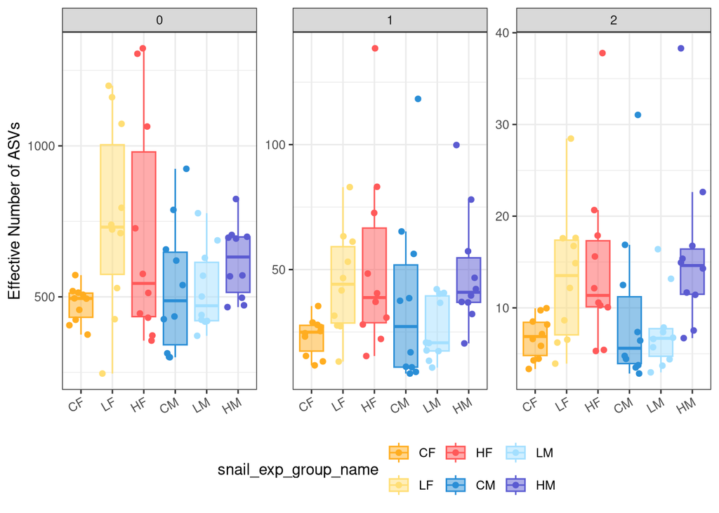

```r
# Plot boxplots by station against diversity
obs_div_df %>%
  ggplot(aes(x = snail_exp_group_name, y = qD, fill = snail_exp_group_name,
             color = snail_exp_group_name)) +
  facet_wrap(.~Order.q, scales = "free_y") +
  geom_jitter() +
  geom_boxplot(alpha = 0.5, outlier.shape = NA) +
  scale_color_manual(values = station_colors) +
  scale_fill_manual(values = station_colors) +
  labs(y = "Effective Number of ASVs") +
  theme_bw() +
  theme(legend.position = "bottom",
        axis.title.x = element_blank(),
        axis.text.x = element_text(angle = 30,
                                   hjust = 1,
                                   vjust = 1))
```

#### Statistically test Richness

```r
# Pull out richness data
obs_rich_df <-
  obs_div_df %>%
  dplyr::filter(Order.q == 0)

# Calculate the kruskall-wallis stats
kw_group_rich <-
  kruskal_test(qD ~ snail_exp_group_name, data = obs_rich_df)

# Look at it
kw_group_rich
```

```
## # A tibble: 1 × 6
##   .y.       n statistic    df      p method
## * <chr> <int>     <dbl> <int>  <dbl> <chr>
## 1 qD       60      9.44     5 0.0928 Kruskal-Wallis
```

```r
# post-hoc test with Dunn's Test
dunn_group_rich <-
  obs_rich_df %>%
  dunn_test(qD ~ snail_exp_group_name, p.adjust.method = "fdr") %>%
  add_xy_position(x = "snail_exp_group_name")

# look at the pairwise
dunn_group_rich
```

```
## # A tibble: 15 × 13
##    .y.   group1 group2    n1    n2 statistic      p p.adj p.adj.signif
##    <chr> <chr>  <chr>  <int> <int>     <dbl>  <dbl> <dbl> <chr>
##  1 qD    CF     LF        10    10     2.47  0.0135 0.202 ns
##  2 qD    CF     HF        10    10     1.48  0.139  0.348 ns
##  3 qD    CF     CM        10    10     0.474 0.636  0.761 ns
##  4 qD    CF     LM        10    10     0.371 0.710  0.761 ns
##  5 qD    CF     HM        10    10     1.85  0.0643 0.241 ns
##  6 qD    LF     HF        10    10    -0.992 0.321  0.482 ns
##  7 qD    LF     CM        10    10    -2.00  0.0458 0.229 ns
##  8 qD    LF     LM        10    10    -2.10  0.0357 0.229 ns
##  9 qD    LF     HM        10    10    -0.621 0.535  0.729 ns
## 10 qD    HF     CM        10    10    -1.01  0.315  0.482 ns
## 11 qD    HF     LM        10    10    -1.11  0.268  0.482 ns
## 12 qD    HF     HM        10    10     0.371 0.710  0.761 ns
## 13 qD    CM     LM        10    10    -0.102 0.918  0.918 ns
## 14 qD    CM     HM        10    10     1.38  0.169  0.361 ns
## 15 qD    LM     HM        10    10     1.48  0.139  0.348 ns
## # ℹ 4 more variables: y.position <dbl>, groups <named list>, xmin <dbl>,
## #   xmax <dbl>
```

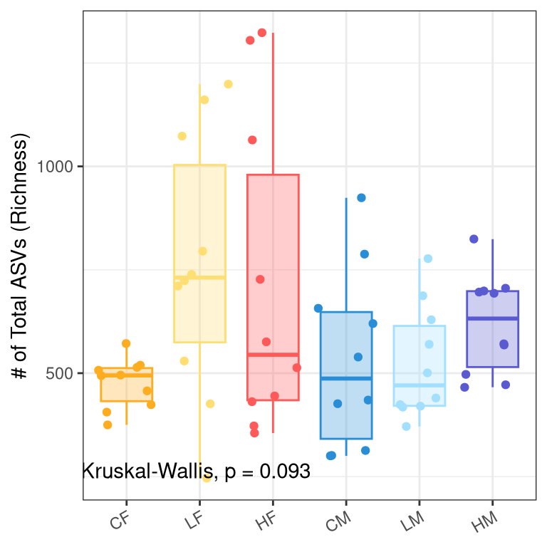

```r
# Richness by station
rich_ggboxplot <-
  ggboxplot(obs_rich_df, x = "snail_exp_group_name", y = "qD",
          color = "snail_exp_group_name", fill = "snail_exp_group_name", alpha = 0.3,
          outlier.shape = NA) +
  # Add points
  geom_jitter(aes(color = snail_exp_group_name)) +
  scale_color_manual(values = station_colors) +
  scale_fill_manual(values = station_colors) +
  labs(y = "# of Total ASVs (Richness)") +
  # Add kruskal & Tukey
  stat_compare_means(method = "kruskal.test", label.y = min(obs_rich_df$qD)) +  # KRUSKAL p-value
  geom_pwc(
    aes(group = snail_exp_group_name), tip.length = 0, hide.ns = TRUE,
    method = "wilcox.test", label = "p.adj.format",
    p.adjust.method = "fdr", bracket.nudge.y = -0.08) +
  theme_bw() +
  theme(legend.position = "none",
        axis.title.x = element_blank(),
        axis.text.x = element_text(angle = 30,
                                   hjust = 1,
                                   vjust = 1))

rich_ggboxplot
```

### Shannon

```r
# Pull out shann data
obs_shan_df <-
  obs_div_df %>%
  dplyr::filter(Order.q == 1)

# Calculate the kruskall wallis since the data NOT NORMAL
kw_group_shan <-
   kruskal_test(qD ~ snail_exp_group_name, data = obs_shan_df)
# Look at it
kw_group_shan
```

```
## # A tibble: 1 × 6
##   .y.       n statistic    df     p method
## * <chr> <int>     <dbl> <int> <dbl> <chr>
## 1 qD       60      13.5     5 0.019 Kruskal-Wallis
```

```r
# post-hoc test with Dunn's Test
dunn_group_shan <-
  obs_shan_df %>%
  dunn_test(qD ~ snail_exp_group_name, p.adjust.method = "fdr") %>%
  add_xy_position(x = "snail_exp_group_name")
# look at the pairwise
dunn_group_shan
```

```
## # A tibble: 15 × 13
##    .y.   group1 group2    n1    n2 statistic       p  p.adj p.adj.signif
##    <chr> <chr>  <chr>  <int> <int>     <dbl>   <dbl>  <dbl> <chr>
##  1 qD    CF     LF        10    10    2.39   0.0167  0.0893 ns
##  2 qD    CF     HF        10    10    2.37   0.0179  0.0893 ns
##  3 qD    CF     CM        10    10    0.871  0.384   0.576  ns
##  4 qD    CF     LM        10    10    0.474  0.636   0.792  ns
##  5 qD    CF     HM        10    10    2.73   0.00639 0.0893 ns
##  6 qD    LF     HF        10    10   -0.0256 0.980   0.980  ns
##  7 qD    LF     CM        10    10   -1.52   0.128   0.224  ns
##  8 qD    LF     LM        10    10   -1.92   0.0548  0.136  ns
##  9 qD    LF     HM        10    10    0.333  0.739   0.792  ns
## 10 qD    HF     CM        10    10   -1.50   0.134   0.224  ns
## 11 qD    HF     LM        10    10   -1.89   0.0581  0.136  ns
## 12 qD    HF     HM        10    10    0.359  0.720   0.792  ns
## 13 qD    CM     LM        10    10   -0.397  0.691   0.792  ns
## 14 qD    CM     HM        10    10    1.86   0.0634  0.136  ns
## 15 qD    LM     HM        10    10    2.25   0.0242  0.0909 ns
## # ℹ 4 more variables: y.position <dbl>, groups <named list>, xmin <dbl>,
## #   xmax <dbl>
```

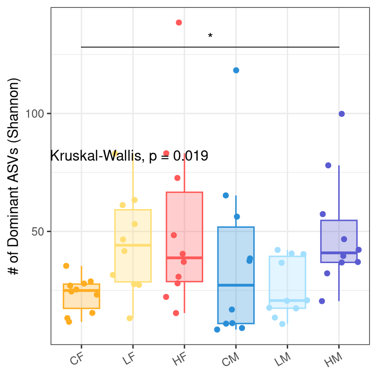

```r
# Shannon by experimental group
shan_ggboxplot <-
  ggboxplot(obs_shan_df, x = "snail_exp_group_name", y = "qD",
          color = "snail_exp_group_name", fill = "snail_exp_group_name", alpha = 0.3,
          outlier.shape = NA) +
  # Add points
  geom_jitter(aes(color = snail_exp_group_name)) +
  scale_color_manual(values = station_colors) +
  scale_fill_manual(values = station_colors) +
  labs(y = "# of Dominant ASVs (Shannon)") +
  # Add kruskal and wilcoxon

  stat_compare_means(method = "kruskal.test", label.y = 80) +  # KRUSKAL p-value (not normal)
  geom_pwc(
    aes(group = snail_exp_group_name), tip.length = 0, hide.ns = TRUE,
    method = "wilcox.test", label = "p.adj.signif",
    step.increase = 0.08,
    p.adjust.method = "fdr", bracket.nudge.y = -0.08) +
  theme_bw() +
  theme(legend.position = "none",
        axis.title.x = element_blank(),
        axis.text.x = element_text(angle = 30,
                                   hjust = 1,
                                   vjust = 1))

shan_ggboxplot
```

### Simpson

```r
# Pull out simpson data
obs_simps_df <-
  obs_div_df %>%
  dplyr::filter(Order.q == 2)

# Calculate the kruskall wallis since the data NOT NORMAL
kw_group_simps <-
   kruskal_test(qD ~ snail_exp_group_name, data = obs_simps_df)
# Look at it
kw_group_simps
```

```
## # A tibble: 1 × 6
##   .y.       n statistic    df       p method
## * <chr> <int>     <dbl> <int>   <dbl> <chr>
## 1 qD       60      15.8     5 0.00736 Kruskal-Wallis
```

```r
# post-hoc test with Dunn's Test
dunn_group_simps <-
  obs_simps_df %>%
  dunn_test(qD ~ snail_exp_group_name, p.adjust.method = "fdr") %>%
  add_xy_position(x = "snail_exp_group_name")
# look at the pairwise
dunn_group_simps
```

```
## # A tibble: 15 × 13
##    .y.   group1 group2    n1    n2 statistic       p  p.adj p.adj.signif
##    <chr> <chr>  <chr>  <int> <int>     <dbl>   <dbl>  <dbl> <chr>
##  1 qD    CF     LF        10    10     2.09  0.0369  0.0895 ns
##  2 qD    CF     HF        10    10     2.30  0.0212  0.0794 ns
##  3 qD    CF     CM        10    10     0.269 0.788   0.908  ns
##  4 qD    CF     LM        10    10     0.154 0.878   0.908  ns
##  5 qD    CF     HM        10    10     2.79  0.00525 0.0583 ns
##  6 qD    LF     HF        10    10     0.218 0.828   0.908  ns
##  7 qD    LF     CM        10    10    -1.82  0.0690  0.115  ns
##  8 qD    LF     LM        10    10    -1.93  0.0532  0.0997 ns
##  9 qD    LF     HM        10    10     0.704 0.481   0.722  ns
## 10 qD    HF     CM        10    10    -2.04  0.0418  0.0895 ns
## 11 qD    HF     LM        10    10    -2.15  0.0315  0.0895 ns
## 12 qD    HF     HM        10    10     0.487 0.627   0.854  ns
## 13 qD    CM     LM        10    10    -0.115 0.908   0.908  ns
## 14 qD    CM     HM        10    10     2.52  0.0117  0.0583 ns
## 15 qD    LM     HM        10    10     2.64  0.00835 0.0583 ns
## # ℹ 4 more variables: y.position <dbl>, groups <named list>, xmin <dbl>,
## #   xmax <dbl>
```

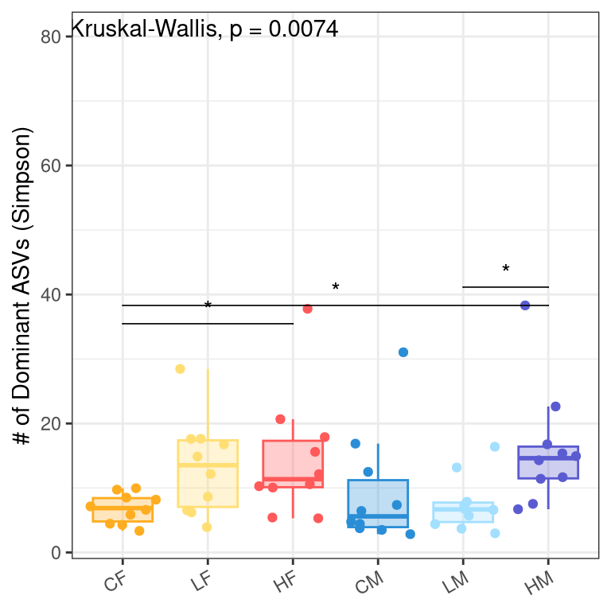

```r
# Simpson by experimental group
simps_ggboxplot <-
  ggboxplot(obs_simps_df, x = "snail_exp_group_name", y = "qD",
          color = "snail_exp_group_name", fill = "snail_exp_group_name", alpha = 0.3,
          outlier.shape = NA) +
  # Add points
  geom_jitter(aes(color = snail_exp_group_name)) +
  scale_color_manual(values = station_colors) +
  scale_fill_manual(values = station_colors) +
  labs(y = "# of Dominant ASVs (Simpson)") +
  # Add kruskal and wilcoxon

  stat_compare_means(method = "kruskal.test", label.y = 80) +  # KRUSKAL p-value (not normal)
  geom_pwc(
    aes(group = snail_exp_group_name), tip.length = 0, hide.ns = TRUE,
    method = "wilcox.test", label = "p.adj.signif",
    step.increase = 0.08,
    p.adjust.method = "fdr", bracket.nudge.y = -0.08) +
  theme_bw() +
  theme(legend.position = "none",
        axis.title.x = element_blank(),
        axis.text.x = element_text(angle = 30,
                                   hjust = 1,
                                   vjust = 1))

simps_ggboxplot
```

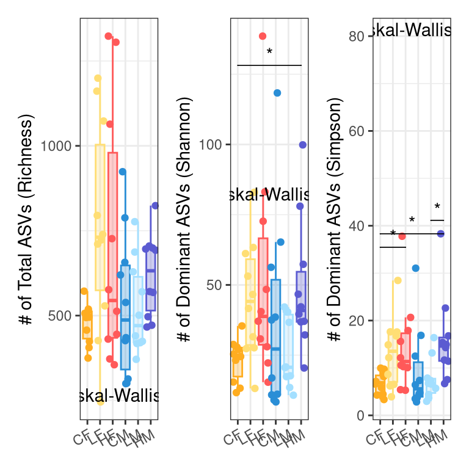

```r
rich_ggboxplot + shan_ggboxplot + simps_ggboxplot
```

INTERPRETATION #2: If you have categorical data, what can you conclude regarding the role that all ASVs (richess, q = 0) versus common ASVs (Shannon, q = 1) versus dominant ASVs (Simpson, q = 2) have on the biodiversity of your samples as it relates to your variable of interest?

Richness: When comparing all to all, every experimental group had statistically the same richness to one another. This means that temperature has no effect on the number of rare ASVs in a snail’s gut, which proves our null hypothesis. Shannon: in all experimental groups, except for control-temperature female and high-temperature male had the same shannon index. This further confirms the null hypothesis suggesting that temperature has no effect on the number of normally abundant ASVs in snail gut. Simpson: Here, we start seeing statistical differences between the experimental groups. CF is significantly different to HF and HM, additionally LM is significantly different to HM, which is exciting! There are statistically significant differences between low-temperature and high-temperature experimental groups. This suggests that for abundant taxons, high temperature results in a significant increase of dominant taxons. This correlates with a finding in the paper, where increased temperatures allowed opportunistic pathogens to proliferate.

```r
# Take the time now that we are at the end of the script
end_time <- Sys.time()
end_time
```

```
## [1] "2025-04-11 01:18:17 EDT"
```